# Introduction

Do higher film budgets lead to more box office revenue? Let's find out if there's a relationship using the movie budgets and financial performance data that I've scraped from [the-numbers.com](https://www.the-numbers.com/movie/budgets) on **May 1st, 2018**.

[figure not shown]

# Import Statements

```python
import pandas as pd
import matplotlib.pyplot as plt
```

# Notebook Presentation

```python
pd.options.display.float_format = '{:,.2f}'.format

from pandas.plotting import register_matplotlib_converters
register_matplotlib_converters()
```

# Read the Data

```python
data = pd.read_csv('cost_revenue_dirty.csv')
```

# Explore and Clean the Data

**Challenge**: Answer these questions about the dataset:

1. How many rows and columns does the dataset contain?
2. Are there any NaN values present?
3. Are there any duplicate rows?
4. What are the data types of the columns?

```python
data
```

|  | Rank | Release_Date | Movie_Title | USD_Production_Budget | USD_Worldwide_Gross | USD_Domestic_Gross |
| --- | --- | --- | --- | --- | --- | --- |
| 0 | 5293 | 8/2/1915 | The Birth of a Nation | $110,000 | $11,000,000 | $10,000,000 |
| 1 | 5140 | 5/9/1916 | Intolerance | $385,907 | $0 | $0 |
| 2 | 5230 | 12/24/1916 | 20,000 Leagues Under the Sea | $200,000 | $8,000,000 | $8,000,000 |
| 3 | 5299 | 9/17/1920 | Over the Hill to the Poorhouse | $100,000 | $3,000,000 | $3,000,000 |
| 4 | 5222 | 1/1/1925 | The Big Parade | $245,000 | $22,000,000 | $11,000,000 |
| ... | ... | ... | ... | ... | ... | ... |
| 5386 | 2950 | 10/8/2018 | Meg | $15,000,000 | $0 | $0 |
| 5387 | 126 | 12/18/2018 | Aquaman | $160,000,000 | $0 | $0 |
| 5388 | 96 | 12/31/2020 | Singularity | $175,000,000 | $0 | $0 |
| 5389 | 1119 | 12/31/2020 | Hannibal the Conqueror | $50,000,000 | $0 | $0 |
| 5390 | 2517 | 12/31/2020 | Story of Bonnie and Clyde, The | $20,000,000 | $0 | $0 |

5391 rows × 6 columns

```python
data.shape
```

```
(5391, 6)
```

```python
data.isna().any()
```

```
Rank                     False
Release_Date             False
Movie_Title              False
USD_Production_Budget    False
USD_Worldwide_Gross      False
USD_Domestic_Gross       False
dtype: bool
```

There are no NaN values.

```python
data.duplicated().sum()
```

```
0
```

There are no exact duplicates.

```python
data.duplicated(subset=['Movie_Title']).any()
```

```
True
```

```python
data.duplicated(subset=['Movie_Title']).sum()
```

```
73
```

There are 73 movies with the same title.

```python
data.loc[data.duplicated(subset=['Movie_Title'])]
```

|  | Rank | Release_Date | Movie_Title | USD_Production_Budget | USD_Worldwide_Gross | USD_Domestic_Gross |
| --- | --- | --- | --- | --- | --- | --- |
| 64 | 3973 | 12/23/1954 | 20,000 Leagues Under the Sea | $5,000,000 | $28,200,000 | $28,200,000 |
| 84 | 2802 | 11/18/1959 | Ben-Hur | $15,000,000 | $73,000,000 | $73,000,000 |
| 215 | 2202 | 12/17/1976 | King Kong | $23,000,000 | $90,614,445 | $52,614,445 |
| 322 | 3105 | 2/4/1982 | Cat People | $12,500,000 | $21,000,000 | $7,000,000 |
| 579 | 4154 | 10/19/1990 | Night of the Living Dead | $4,200,000 | $5,835,247 | $5,835,247 |
| ... | ... | ... | ... | ... | ... | ... |
| 5289 | 725 | 12/8/2016 | Pete’s Dragon | $65,000,000 | $137,768,975 | $76,233,151 |
| 5330 | 115 | 3/17/2017 | Beauty and the Beast | $160,000,000 | $1,260,122,363 | $504,014,165 |
| 5334 | 891 | 3/24/2017 | Life | $58,000,000 | $100,993,260 | $30,223,972 |
| 5342 | 3180 | 4/21/2017 | Unforgettable | $12,000,000 | $15,668,012 | $11,368,012 |
| 5375 | 57 | 9/6/2017 | The Mummy | $195,000,000 | $397,644,453 | $79,741,080 |

73 rows × 6 columns

```python
data.duplicated(subset=['Movie_Title', 'Release_Date']).sum()
```

```
1
```

```python
data.loc[data.duplicated(subset=['Movie_Title', 'Release_Date']).sum()].to_frame().transpose()
```

|  | Rank | Release_Date | Movie_Title | USD_Production_Budget | USD_Worldwide_Gross | USD_Domestic_Gross |
| --- | --- | --- | --- | --- | --- | --- |
| 1 | 5140 | 5/9/1916 | Intolerance | $385,907 | $0 | $0 |

Only 1 movie as duplicate, with the same release date and same title.

```python
data.dtypes
```

```
Rank                      int64
Release_Date             object
Movie_Title              object
USD_Production_Budget    object
USD_Worldwide_Gross      object
USD_Domestic_Gross       object
dtype: object
```

```python
data.info()
```

```
<class 'pandas.core.frame.DataFrame'>
RangeIndex: 5391 entries, 0 to 5390
Data columns (total 6 columns):
 #   Column                 Non-Null Count  Dtype
---  ------                 --------------  -----
 0   Rank                   5391 non-null   int64
 1   Release_Date           5391 non-null   object
 2   Movie_Title            5391 non-null   object
 3   USD_Production_Budget  5391 non-null   object
 4   USD_Worldwide_Gross    5391 non-null   object
 5   USD_Domestic_Gross     5391 non-null   object
dtypes: int64(1), object(5)
memory usage: 252.8+ KB
```

Only the "Rank" is an integer, the rest are objects (could be strings).

Also, `.info()` gives us the "Non-Null Count" which is pretty useful.

### Data Type Conversions

**Challenge**: Convert the `USD_Production_Budget`, `USD_Worldwide_Gross`, and `USD_Domestic_Gross` columns to a numeric format by removing `$` signs and `,`.  
Note that *domestic* in this context refers to the United States.

```python
data_clean = data
data_clean.USD_Production_Budget = data_clean.USD_Production_Budget.astype('str').str.replace('$', '', regex=False).str.replace(',', '', regex=False).astype('int64')
data_clean.USD_Domestic_Gross = data_clean.USD_Domestic_Gross.astype('str').str.replace('$', '', regex=False).str.replace(',', '', regex=False).astype('int64')
data_clean.USD_Worldwide_Gross = data_clean.USD_Worldwide_Gross.astype('str').str.replace('$', '', regex=False).str.replace(',', '', regex=False).astype('int64')
data_clean.sample(3)
```

|  | Rank | Release_Date | Movie_Title | USD_Production_Budget | USD_Worldwide_Gross | USD_Domestic_Gross |
| --- | --- | --- | --- | --- | --- | --- |
| 2712 | 755 | 7/14/2006 | Little Man | 64000000 | 101636047 | 58636047 |
| 1822 | 1387 | 6/9/2002 | City by the Sea | 40000000 | 22433915 | 22433915 |
| 181 | 3714 | 6/27/1973 | Live and Let Die | 7000000 | 161800000 | 35400000 |

**Challenge**: Convert the `Release_Date` column to a Pandas Datetime type.

```python
data_clean.Release_Date = pd.to_datetime(data_clean.Release_Date)
data_clean.sample(1)
```

|  | Rank | Release_Date | Movie_Title | USD_Production_Budget | USD_Worldwide_Gross | USD_Domestic_Gross |
| --- | --- | --- | --- | --- | --- | --- |
| 1764 | 678 | 2002-02-15 | Hart's War | 70000000 | 33076815 | 19076815 |

```python
data_clean.info()
```

```
<class 'pandas.core.frame.DataFrame'>
RangeIndex: 5391 entries, 0 to 5390
Data columns (total 6 columns):
 #   Column                 Non-Null Count  Dtype
---  ------                 --------------  -----
 0   Rank                   5391 non-null   int64
 1   Release_Date           5391 non-null   datetime64[ns]
 2   Movie_Title            5391 non-null   object
 3   USD_Production_Budget  5391 non-null   int64
 4   USD_Worldwide_Gross    5391 non-null   int64
 5   USD_Domestic_Gross     5391 non-null   int64
dtypes: datetime64[ns](1), int64(4), object(1)
memory usage: 252.8+ KB
```

We now have datetime and int64 data types.

```python
data_clean.tail()
```

|  | Rank | Release_Date | Movie_Title | USD_Production_Budget | USD_Worldwide_Gross | USD_Domestic_Gross |
| --- | --- | --- | --- | --- | --- | --- |
| 5386 | 2950 | 2018-10-08 | Meg | 15000000 | 0 | 0 |
| 5387 | 126 | 2018-12-18 | Aquaman | 160000000 | 0 | 0 |
| 5388 | 96 | 2020-12-31 | Singularity | 175000000 | 0 | 0 |
| 5389 | 1119 | 2020-12-31 | Hannibal the Conqueror | 50000000 | 0 | 0 |
| 5390 | 2517 | 2020-12-31 | Story of Bonnie and Clyde, The | 20000000 | 0 | 0 |

Warning: Null are not zero values!

NULLs are used to signify missing data. In Python we normally use `None` to signal such a situation. Since numeric numpy arrays (an underlying datastructure in a dataframe) cannot hold `None` values, Pandas uses `NaN` as NULLs instead.

As such the `pandas.isnull()` function will only detect `NaN` or `None` values.

# Investigating the Zero Revenue Films

### Descriptive Statistics

**Challenge**:

1. What is the average production budget of the films in the data set?
2. What is the average worldwide gross revenue of films?
3. What were the minimums for worldwide and domestic revenue?
4. Are the bottom 25% of films actually profitable or do they lose money?
5. What are the highest production budget and highest worldwide gross revenue of any film?
6. How much revenue did the lowest and highest budget films make?

```python
print("The average production budget of the films is: ${:,.2f}".format(data_clean.USD_Production_Budget.mean()))
```

```
The average production budget of the films is: $31,113,737.58
```

```python
print("The average worldwide gross revenue of the films is: ${:,.2f}".format(data_clean.USD_Worldwide_Gross.mean()))
```

```
The average worldwide gross revenue of the films is: $88,855,421.96
```

```python
data_clean[['USD_Production_Budget', 'USD_Worldwide_Gross', 'USD_Domestic_Gross']].describe()
```

|  | USD_Production_Budget | USD_Worldwide_Gross | USD_Domestic_Gross |
| --- | --- | --- | --- |
| count | 5,391.00 | 5,391.00 | 5,391.00 |
| mean | 31,113,737.58 | 88,855,421.96 | 41,235,519.44 |
| std | 40,523,796.88 | 168,457,757.00 | 66,029,346.27 |
| min | 1,100.00 | 0.00 | 0.00 |
| 25% | 5,000,000.00 | 3,865,206.00 | 1,330,901.50 |
| 50% | 17,000,000.00 | 27,450,453.00 | 17,192,205.00 |
| 75% | 40,000,000.00 | 96,454,455.00 | 52,343,687.00 |
| max | 425,000,000.00 | 2,783,918,982.00 | 936,662,225.00 |

```python
data_clean.loc[data.USD_Domestic_Gross > data.USD_Worldwide_Gross]
```

|  | Rank | Release_Date | Movie_Title | USD_Production_Budget | USD_Worldwide_Gross | USD_Domestic_Gross |
| --- | --- | --- | --- | --- | --- | --- |

--> None, this is indicative that the Worldwide Gross indeed includes the Domestic Gross

**Analysis:** The average film costs about \$31m to make and makes around 3x that (or ~\\$89m) in worldwide revenue. So that's encouraging.

But quite a lot of films lose money too. In fact, all the films in the bottom 25% lose money, since the average cost is \$5 million and they only bring in \\$3.8m in worldwide revenue!

The minimum domestic and worldwide revenue is \$0. That makes sense. If a film never gets screened or is cancelled, then this is the number we would expect to see here.

On the other hand, the highest production budget was \$425,000,000 and the highest worldwide revenue was \\$2,783,918,982. $2.7 Billion revenue! Holy smokes.

```python
data_clean.loc[data_clean.USD_Production_Budget == data_clean.USD_Production_Budget.min()]
```

|  | Rank | Release_Date | Movie_Title | USD_Production_Budget | USD_Worldwide_Gross | USD_Domestic_Gross |
| --- | --- | --- | --- | --- | --- | --- |
| 2427 | 5391 | 2005-05-08 | My Date With Drew | 1100 | 181041 | 181041 |

The lowest production budget (\$1100) made a revenue of \\$181,041!

```python
data_clean.loc[data_clean.USD_Production_Budget == data_clean.USD_Production_Budget.max()]
```

|  | Rank | Release_Date | Movie_Title | USD_Production_Budget | USD_Worldwide_Gross | USD_Domestic_Gross |
| --- | --- | --- | --- | --- | --- | --- |
| 3529 | 1 | 2009-12-18 | Avatar | 425000000 | 2783918982 | 760507625 |

The highest budget also has the highest revenue.

**Challenge** How many films grossed $0 domestically (i.e., in the United States)?

```python
zero_domestic_revenue_films = data_clean.loc[data_clean.USD_Domestic_Gross == 0]
zero_domestic_revenue_films.Movie_Title.count()
```

```
512
```

What were the highest budget films that grossed nothing?

```python
zero_domestic_revenue_films.sort_values('USD_Production_Budget', ascending=False).head()
```

|  | Rank | Release_Date | Movie_Title | USD_Production_Budget | USD_Worldwide_Gross | USD_Domestic_Gross |
| --- | --- | --- | --- | --- | --- | --- |
| 5388 | 96 | 2020-12-31 | Singularity | 175000000 | 0 | 0 |
| 5387 | 126 | 2018-12-18 | Aquaman | 160000000 | 0 | 0 |
| 5384 | 321 | 2018-09-03 | A Wrinkle in Time | 103000000 | 0 | 0 |
| 5385 | 366 | 2018-10-08 | Amusement Park | 100000000 | 0 | 0 |
| 5090 | 556 | 2015-12-31 | Don Gato, el inicio de la pandilla | 80000000 | 4547660 | 0 |

We see that there are 512 films in the dataset that had no revenue in the United States. However, the highest budget films with no revenue have a release date AFTER the date on which the **dataset was compiled (May 1st, 2018).**

**Challenge**: How many films grossed $0 worldwide?

```python
zero_worldwide_revenue_films = data_clean.loc[data_clean.USD_Worldwide_Gross == 0]
zero_worldwide_revenue_films.Movie_Title.count()
```

```
357
```

What are the highest budget films that had no revenue internationally?

```python
zero_worldwide_revenue_films.sort_values('USD_Production_Budget', ascending=False).head()
```

|  | Rank | Release_Date | Movie_Title | USD_Production_Budget | USD_Worldwide_Gross | USD_Domestic_Gross |
| --- | --- | --- | --- | --- | --- | --- |
| 5388 | 96 | 2020-12-31 | Singularity | 175000000 | 0 | 0 |
| 5387 | 126 | 2018-12-18 | Aquaman | 160000000 | 0 | 0 |
| 5384 | 321 | 2018-09-03 | A Wrinkle in Time | 103000000 | 0 | 0 |
| 5385 | 366 | 2018-10-08 | Amusement Park | 100000000 | 0 | 0 |
| 5058 | 880 | 2015-11-12 | The Ridiculous 6 | 60000000 | 0 | 0 |

When we check worldwide revenue instead, we see that there are 357 films that made no money internationally. Once again, some of the films have not been released yet at the time the data was compiled. However, 512 versus 357. Why is there a difference?

The reason some international films were never screened in the United States. In fact, we can see an example of this in our previous screenshot. "Don Gato, el inicio de la pandilla" made about \$4.5 million dollars in the box office, but nothing in the United States. Perhaps they should have screened it there too, considering it cost \\$80 million to make!

### Filtering on Multiple Conditions

So far, we've created subsets for our DataFrames based on a single condition. But what if we want to select our data based on more than one condition? For example, which films made money internationally (i.e., `data.USD_Worldwide_Gross != 0`), but had zero box office revenue in the United States (i.e., `data.USD_Domestic_Gross == 0`)?

How would we create a filter for these two conditions? One approach is to use the `.loc[]` property combined with the bitwise `&` AND operator.

```python
international_releases = data_clean.loc[(data_clean.USD_Worldwide_Gross != 0) & (data_clean.USD_Domestic_Gross == 0)]
international_releases.sample(3)
```

|  | Rank | Release_Date | Movie_Title | USD_Production_Budget | USD_Worldwide_Gross | USD_Domestic_Gross |
| --- | --- | --- | --- | --- | --- | --- |
| 3308 | 4453 | 2008-12-31 | Rejsen til Saturn | 2700000 | 5377665 | 0 |
| 4893 | 3939 | 2015-05-05 | Miss Julie | 5500000 | 863895 | 0 |
| 4765 | 4415 | 2014-12-31 | Demonic | 3000000 | 4668109 | 0 |

Why does this work? Pandas is built on top of NumPy, which uses Python's bitwise operators. And these bitwise operators allow us to do comparisons on an element by element basis in both NumPy and Pandas! Here's an example:

[figure not shown]

However, we're also checking if the domestic revenue was zero and the worldwide revenue was not zero. Because the bitwise operator takes precedence, we need to include parentheses `()` around the comparisons we'd like to prioritise.

However, this is not the only technique we can use to make multiple comparisons.

**Challenge**: Use the [`.query()` function](https://pandas.pydata.org/pandas-docs/stable/reference/api/pandas.DataFrame.query.html) to accomplish the same thing. Create a subset for international releases that had some worldwide gross revenue, but made zero revenue in the United States.

Hint: This time you'll have to use the `and` keyword.

```python
international_releases_v2 = data_clean.query("USD_Worldwide_Gross!=0 and USD_Domestic_Gross==0")
international_releases_v2.sample(2)
```

|  | Rank | Release_Date | Movie_Title | USD_Production_Budget | USD_Worldwide_Gross | USD_Domestic_Gross |
| --- | --- | --- | --- | --- | --- | --- |
| 5091 | 1271 | 2015-12-31 | Pourquoi j'ai pas mangé mon père | 42000000 | 182156 | 0 |
| 4714 | 5175 | 2014-10-31 | All You Need Is Love | 300000 | 177507 | 0 |

**N.B.** Must use the `@` if use of a variable in the query string

### Unreleased Films

**Challenge**:

- Identify which films were not released yet as of the time of data collection (May 1st, 2018).
- How many films are included in the dataset that have not yet had a chance to be screened in the box office?
- Create another DataFrame called data_clean that does not include these films.

```python
# Date of Data Collection
scrape_date = pd.Timestamp('2018-5-1')
print(type(scrape_date))
```

```
<class 'pandas._libs.tslibs.timestamps.Timestamp'>
```

```python
print(type(data_clean.Release_Date[0]))
```

```
<class 'pandas._libs.tslibs.timestamps.Timestamp'>
```

I guess it's better to use the pd.Timestamp() constructor, since Release_Date are also pd.Timestamp objects.

Otherwise, datetime constructor:

```python
import datetime
release_date = datetime.datetime(year=2018, month=5, day=1)
print(release_date)
print(type(release_date))
```

```
2018-05-01 00:00:00
<class 'datetime.datetime'>
```

```python
unreleased = data_clean.loc[data_clean.Release_Date > scrape_date]
unreleased
```

|  | Rank | Release_Date | Movie_Title | USD_Production_Budget | USD_Worldwide_Gross | USD_Domestic_Gross |
| --- | --- | --- | --- | --- | --- | --- |
| 5384 | 321 | 2018-09-03 | A Wrinkle in Time | 103000000 | 0 | 0 |
| 5385 | 366 | 2018-10-08 | Amusement Park | 100000000 | 0 | 0 |
| 5386 | 2950 | 2018-10-08 | Meg | 15000000 | 0 | 0 |
| 5387 | 126 | 2018-12-18 | Aquaman | 160000000 | 0 | 0 |
| 5388 | 96 | 2020-12-31 | Singularity | 175000000 | 0 | 0 |
| 5389 | 1119 | 2020-12-31 | Hannibal the Conqueror | 50000000 | 0 | 0 |
| 5390 | 2517 | 2020-12-31 | Story of Bonnie and Clyde, The | 20000000 | 0 | 0 |

```python
unreleased.Movie_Title.count()
```

```
7
```

**Note:** I can also use `len()` instead of `.count()` on a specific column.

```python
len(unreleased)
```

```
7
```

**Trick to remove a dataframe from another dataframe:**

`data_clean - unreleased` doesn't work.

[See StackOverflow solution](https://stackoverflow.com/questions/37313691/how-to-remove-a-pandas-dataframe-from-another-dataframe)

Use `pd.concat` followed by `drop_duplicates(keep=False)`

```
pd.concat([df1, df2, df2]).drop_duplicates(keep=False)
```

`pd.concat` adds the two DataFrames together by appending one right after the other. if there is any overlap, it will be captured by the `drop_duplicates` method. However, `drop_duplicates` by default leaves the first observation and removes every other observation. In this case, we want every duplicate removed. Hence, the `keep=False` parameter which does exactly that.

A special note to the repeated df2. **With only one df2 any row in df2 not in df1 won't be considered a duplicate and will remain.** This solution with only one df2 only works when df2 is a subset of df1. However, **if we concat df2 twice, it is guaranteed to be a duplicate and will subsequently be removed.**

```python
data_clean = pd.concat([data_clean, unreleased, unreleased]).drop_duplicates(keep=False)
```

```python
data_clean.loc[data_clean.Release_Date > scrape_date].Movie_Title.count()
```

```
0
```

A less complicated move would have been to use the `.drop()` method with the index:

```
data_clean = data.drop(unreleased.index)
```

[See documentation](https://pandas.pydata.org/docs/reference/api/pandas.DataFrame.drop.html?highlight=drop#pandas.DataFrame.drop) to know what type of arguments `.drop()` takes -> can take index or column labels.

### Films that Lost Money

**Challenge**: What is the percentage of films where the production costs exceeded the worldwide gross revenue?

```python
unprofitable = data_clean.loc[data_clean.USD_Production_Budget > data_clean.USD_Worldwide_Gross]
print(f"{len(unprofitable)} unprofitable movies out of {len(data_clean)}")
```

```
2007 unprofitable movies out of 5384
```

```python
percent = round(len(unprofitable)/len(data_clean) * 100, 2)
print(f"{percent}% of movies were not profitable.")
```

```
37.28% of movies were not profitable.
```

We see that a whopping 37.2% 😮 of films do not recoup their production budget at the box office. 💸 💸 💸 Who knew that film finance could be so risky! 😬

# Seaborn for Data Viz: Bubble Charts

```python
import seaborn as sns
```

To create a `.scatterplot()`, all we need to do is supply our DataFrame and the column names that we'd like to see on our axes.

And because Seaborn is built on top of Matplotlib, we can dive into the Matplotlib layer anytime to configure our chart. For example, we can increase the size of our figure with `.figure()`. Parameter reminder from documentation:

> figsize : (float, float), default: rcParams["figure.figsize"] (default: [6.4, 4.8]) --> Width, height in inches.

Finally, the Seaborn `.scatterplot()` method actually returns the matplotlib Axes ([see doc](https://seaborn.pydata.org/generated/seaborn.scatterplot.html)), so to style our chart we can simply configure the Axes object

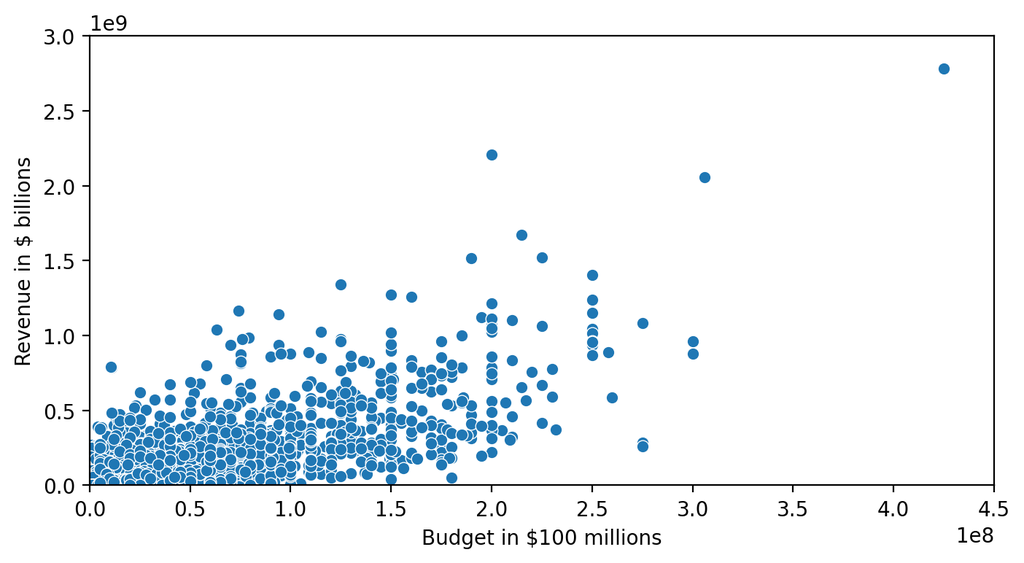

```python
plt.figure(figsize=(8,4), dpi=200)
ax = sns.scatterplot(data=data_clean, x='USD_Production_Budget', y='USD_Worldwide_Gross')
ax.set(ylim=(0, 3000000000), xlim=(0, 450000000), ylabel='Revenue in $ billions', xlabel='Budget in $100 millions')
plt.show()
```

But the reason we're using Seaborn is because of the `hue` and `size` parameters that make it very easy to create a bubble chart. These parameters allow us to colour the data and change their size according to one of the columns in our DataFrame.

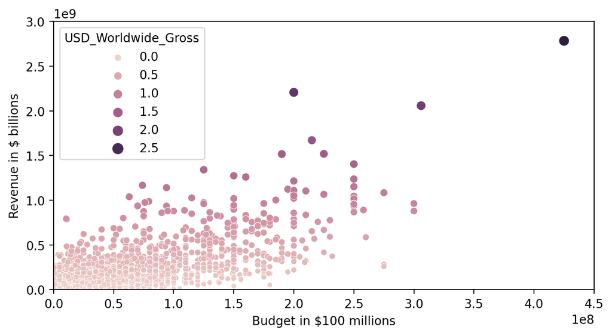

```python
plt.figure(figsize=(8,4), dpi=200)
ax = sns.scatterplot(data=data_clean, x='USD_Production_Budget', y='USD_Worldwide_Gross',
                    hue='USD_Worldwide_Gross', size='USD_Worldwide_Gross')  # changing dot size and colour
ax.set(ylim=(0, 3000000000), xlim=(0, 450000000), ylabel='Revenue in $ billions', xlabel='Budget in $100 millions')
plt.show()
```

Now our higher grossing movies are bigger and darker on our chart. That's super handy. But Seaborn offers a number of convenient styling options as well.

To set the styling on a single chart (as opposed to all the charts in the entire notebook) we can use Python's `with` keyword. We've seen `with` used already when it comes to opening files in previous lessons.

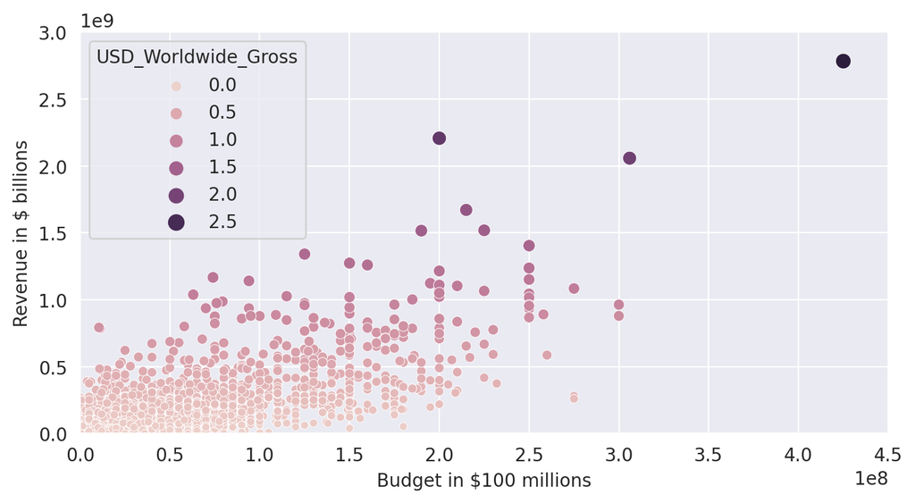

```python
plt.figure(figsize=(8,4), dpi=200)

# set styling on a single chart
with sns.axes_style('darkgrid'):
    ax = sns.scatterplot(data=data_clean, x='USD_Production_Budget', y='USD_Worldwide_Gross',
                        hue='USD_Worldwide_Gross', size='USD_Worldwide_Gross')  # changing dot size and colour
    ax.set(ylim=(0, 3000000000), xlim=(0, 450000000), ylabel='Revenue in $ billions', xlabel='Budget in $100 millions')

plt.show()
```

In addition to `'darkgrid'`, Seaborn has a number of built-in themes. so you can style your chart very quickly. Try out `'whitegrid'`, `'dark'`, or `'ticks'` for example.

### Plotting Movie Releases over Time

**Challenge**: Try to create [this Bubble Chart](https://img-c.udemycdn.com/redactor/raw/2020-10-15_09-44-00-eac16a0a1c99356a123eb410d99157ec.png):

```python
data_clean.sample(2)
```

|  | Rank | Release_Date | Movie_Title | USD_Production_Budget | USD_Worldwide_Gross | USD_Domestic_Gross |
| --- | --- | --- | --- | --- | --- | --- |
| 2716 | 592 | 2006-07-21 | Monster House | 75000000 | 141267370 | 73661010 |
| 1138 | 5300 | 1998-09-10 | The Mighty | 100000 | 6121582 | 2652246 |

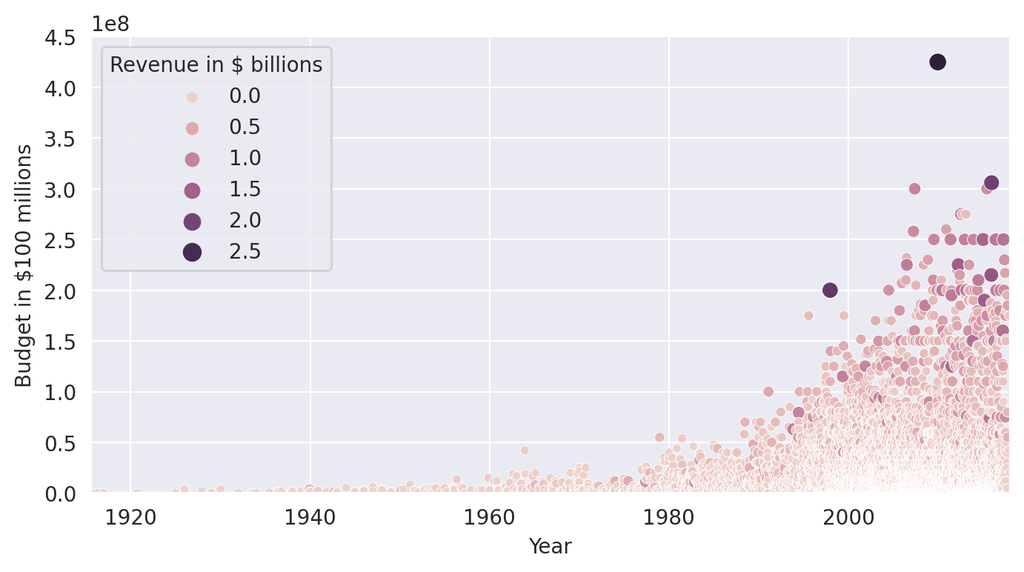

```python
plt.figure(figsize=(8,4), dpi=200)

# set styling on a single chart
with sns.axes_style('darkgrid'):
    ax = sns.scatterplot(data=data_clean, x='Release_Date', y='USD_Production_Budget',
                        hue='USD_Worldwide_Gross', size='USD_Worldwide_Gross')
    ax.set(ylim=(0, 450000000), xlim=(data_clean.Release_Date.min(), data_clean.Release_Date.max()),
           ylabel='Budget in $100 millions', xlabel='Year')
    ax.legend(title='Revenue in $ billions',
              # ncols=2
             )
plt.show()
```

# Converting Years to Decades Trick

**Challenge**: Create a column in `data_clean` that has the decade of the release.

[figure not shown]

**Own solution**:

Use `.dt` to access the datetime/timestamp method and attributes on a Series.

```python
decade = data_clean.Release_Date.dt.year // 10 * 10  # get hold of the year, then floor division by 10, then x10
data_clean['Decade'] = decade
data_clean.sample(10)
```

|  | Rank | Release_Date | Movie_Title | USD_Production_Budget | USD_Worldwide_Gross | USD_Domestic_Gross | Decade |
| --- | --- | --- | --- | --- | --- | --- | --- |
| 81 | 4016 | 1959-01-01 | Solomon and Sheba | 5000000 | 11000000 | 11000000 | 1950 |
| 2391 | 2084 | 2005-03-18 | Ice Princess | 25000000 | 25732334 | 24381334 | 2000 |
| 2797 | 5012 | 2006-11-08 | Half Nelson | 700000 | 4911725 | 2697938 | 2000 |
| 1244 | 4766 | 1999-05-03 | Lock, Stock and Two Smoking Barrels | 1350000 | 28356188 | 3897569 | 1990 |
| 4877 | 4521 | 2015-04-15 | The Toxic Avenger Part II | 2300000 | 0 | 0 | 2010 |
| 896 | 1188 | 1996-08-16 | Tin Cup | 45000000 | 75854588 | 53854588 | 1990 |
| 263 | 3805 | 1980-01-01 | Dressed to Kill | 6500000 | 31899000 | 31899000 | 1980 |
| 4841 | 5214 | 2015-03-02 | UnDivided | 250000 | 0 | 0 | 2010 |
| 5084 | 360 | 2015-12-25 | Point Break | 100000000 | 128131571 | 28782481 | 2010 |
| 2975 | 2027 | 2007-09-11 | No Country for Old Men | 25000000 | 164051250 | 74273505 | 2000 |

**Course solution**:

1. Create a DatetimeIndex object from the Release_Date column. To create a DatetimeIndex, we just call the constructor and provide our release date column as an argument to initialise the DatetimeIndex object: `dt_index = pd.DatetimeIndex(data_clean.Release_Date)`
2. Then we can extract all the years from the DatetimeIndex: `years = dt_index.year`
3. Now, all we need to do is convert the years to decades. For that, we will use floor division (aka integer division). The difference to regular division is that the result is effectively rounded down. In our case, we will use the floor division by 10 and then multiplication by 10 to convert the release year to the release decade. We can do this for all the years: `decades = years//10*10`
4. And then add the decades back as a column: `data_clean['Decade'] = decades`

### Separate the "old" (before 1969) and "New" (1970s onwards) Films

**Challenge**: Create two new DataFrames: `old_films` and `new_films`

- `old_films` should include all the films before 1969 (up to and including 1969)
- `new_films` should include all the films from 1970 onwards
- How many films were released prior to 1970?
- What was the most expensive film made prior to 1970?

```python
old_date = pd.Timestamp('1970-1-1')
old_films = data_clean.loc[data_clean.Release_Date < old_date]
new_films = data_clean.loc[data_clean.Release_Date >= old_date]
```

Or we could have used the `Decade` column:

```
old_films = data_clean[data_clean.Decade <= 1960]
new_films = data_clean[data_clean.Decade > 1960]
```

```python
print(f"{len(old_films)} films were released prior to 1970.")
print(f"{len(new_films)} films were released from 1970 onwards.")
```

```
153 films were released prior to 1970.
5231 films were released from 1970 onwards.
```

```python
old_films.loc[old_films.USD_Production_Budget == old_films.USD_Production_Budget.max()]
```

|  | Rank | Release_Date | Movie_Title | USD_Production_Budget | USD_Worldwide_Gross | USD_Domestic_Gross | Decade |
| --- | --- | --- | --- | --- | --- | --- | --- |
| 109 | 1253 | 1963-12-06 | Cleopatra | 42000000 | 71000000 | 57000000 | 1960 |

This is the most expansive film made prior to 1970.

# Seaborn Regression Plots

`.regplot()` plots the relationship between two variables in a DataFrame.

This creates a scatter plot and draws a linear regression line together with the confidence interval at the same time.

To style the chart further, we can once again, drop into the Matplotlib layer and supply keyword arguments as dictionaries. We can customise the scatter plot (e.g., by changing the transparency of the dots) and the regression line itself (e.g., by changing the colour).

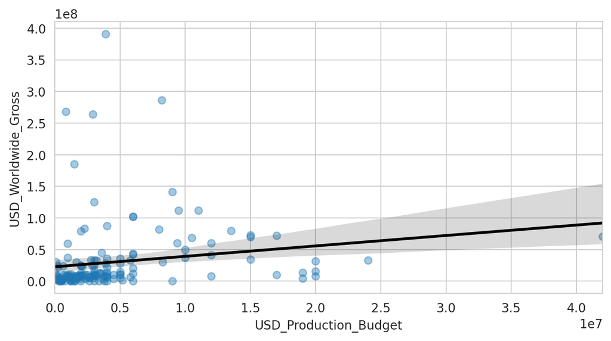

```python
plt.figure(figsize=(8,4), dpi=200)
with sns.axes_style("whitegrid"):
    ax = sns.regplot(data=old_films,
            x='USD_Production_Budget',
            y='USD_Worldwide_Gross',
            scatter_kws = {'alpha': 0.4},  # changing transparency of the scatter dots
            line_kws = {'color': 'black'})  # changing colour of the regression line
    ax.set(xlim=(0, old_films.USD_Production_Budget.max()))
plt.show()
```

What do we see here? Well, first off we can spot Cleopatra on the far right. But also, we see that many lower budget films made much more money! The relationship between the production budget and movie revenue is not very strong. Many points on the left are very far away for the line, so the line appears not to capture the relationship between budget and revenue very well at all!

But does the same hold true for the newer films?

**Challenge**: Use Seaborn's `.regplot()` to show the scatter plot and linear regression line against the `new_films`.  
Style the chart

- Put the chart on a `'darkgrid'`.
- Set limits on the axes so that they don't show negative values.
- Label the axes on the plot "Revenue in \$ billions" and "Budget in \\$ millions".
- Provide HEX colour codes for the plot and the regression line. Make the dots dark blue (#2f4b7c) and the line orange (#ff7c43).

**Note:** The `scatter_kws` dict passes arguments to `plt.scatter` from matplotlib, and `line_kws` to `plt.plot`

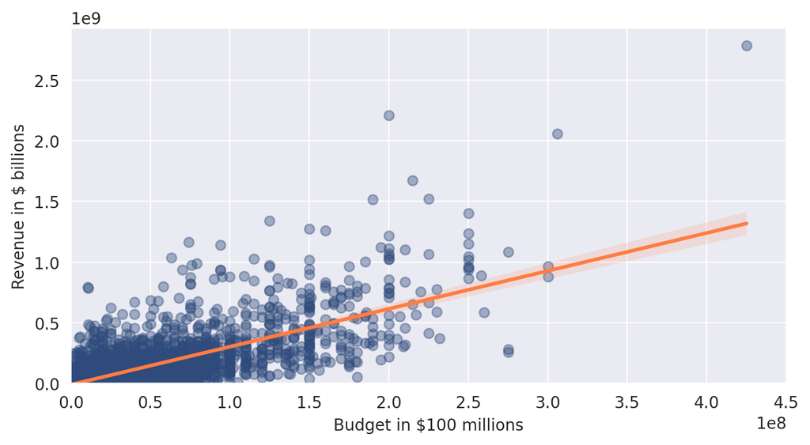

```python
plt.figure(figsize=(8,4), dpi=200)
with sns.axes_style("darkgrid"):
    ax = sns.regplot(data=new_films,
            x='USD_Production_Budget',
            y='USD_Worldwide_Gross',
            scatter_kws = {'alpha': 0.4, 'color': '#2f4b7c'}, # dots transparent and dark blue
            line_kws = {'color': '#ff7c43'})  # reg line orange colour
    ax.set(xlim=(0, 450000000),
           ylabel='Revenue in $ billions', xlabel='Budget in $100 millions')
    ax.set_ylim(bottom=0) # just setting the min limit
plt.show()
```

Interpret the chart

- Do our data points for the new films align better or worse with the linear regression than for our older films?
- Roughly how much would a film with a budget of \$150 million make according to the regression line?

How do we interpret our chart? This time we are getting a much better fit, compared to the old films. We can see this visually from the fact that our data points line up much better with our regression line (pun intended). Also, the **confidence interval** is much narrower. We also see that **a film with a \$150 million budget is predicted to make slightly under \\$500 million** by our regression line.

All in all, we can be pretty confident that there does indeed seem to be a relationship between a film's budget and that film's worldwide revenue.

But how much of the variation in revenue does the budget actually explain? And how much extra revenue can we expect for an additional $1 increase in the budget? To find out, we need to dive into the numbers underlying our regression model.

# Run Your Own Regression with scikit-learn

$$ REV \hat ENUE = \theta _0 + \theta _1 BUDGET$$

Let's dive into our linear regression model a bit more. We are using a **univariate regression**. This is a regression with a **single explanatory variable** (our movie BUDGET). Explanatory variables are also referred to as **features** in machine learning terminology.

Using our data on budgets, the linear regression estimates the best possible line to fit our movie revenues. The regression line has the following structure:

[figure not shown]

To find the best possible line, our regression will estimate the **y-intercept ("theta zero")** and the **slope ("theta one")**. The line's intercept on the y-axis tells us how much revenue a movie would make if the budget was 0. The slope tells us how much extra revenue we get for a $1 increase in the movie budget.

[figure not shown]

So how can we find out what our model's estimates are for theta-one and theta-zero? And how can we run our own regression, regardless of whether we want to visualise it on a chart? For that, we can use **[scikit-learn](https://scikit-learn.org/stable/)**.

*Import scikit-learn*

Let's add the `LinearRegression` from scikit-learn to our notebook.

```python
from sklearn.linear_model import LinearRegression
```

Now we can run a LinearRegression. First, let's create a `LinearRegression` object that will do the work for us:

```python
regression = LinearRegression()
```

Now we should specify our features and our targets (i.e., our response variable). You will often see the features named capital `X` and the target named lower case `y`. Our `LinearRegression` does not like receiving Pandas Series so we create DataFrames.

```python
# Explanatory Variable(s) or Feature(s)
X = new_films.USD_Production_Budget.to_frame()

# Response Variable or Target
y = new_films.USD_Worldwide_Gross.to_frame()
```

Now it's time to get to work and run the calculations:

```python
# Find the best-fit line
regression.fit(X, y)
```

```
LinearRegression()
```

That's it. Now we can look at the values of theta-one and theta-zero from the equation above.

```python
# Theta zero
regression.intercept_
```

```
array([-8650768.00661038])
```

```python
# Theta one
regression.coef_
```

```
array([[3.12259592]])
```

Both `intercept_` and `coef_` are simply attributes of the LinearRegression object. Don't worry about the underscores at the end, these are simply part of the attribute names that the scikit-learn developers have chosen.

How do we interpret the y-intercept? Literally, it means that if a movie budget is \$0, the estimated movie revenue is -\\$8.65 million. Hmm... so this is clearly unrealistic. Why would our model tell us such nonsense? Well, the reason is that we are specifying what the model should be ahead of time - namely a straight line - and then finding the best straight line for our data. Considering that you can't have negative revenue or a negative budget, we have to be careful about interpreting our very simple model too literally. After all, it's just an estimate and this estimate will be the most accurate on the chart where we have the most data points (rather than at the extreme left or right).

What about the slope? The slope tells us that for every extra \$1 in the budget, movie revenue increases by \\$3.1. So, that's pretty interesting. That means the higher our budget, the higher our estimated revenue. If budgets are all that matter to make lots of money, then studio executives and film financiers should try and produce the biggest films possible, right? Maybe that's exactly why we've seen a massive increase in budgets over the past 30 years.

**R-Squared: Goodness of Fit**

One measure of figuring out how well our model fits our data is by looking at a metric called **r-squared**. This is a good number to look at in addition to eyeballing our charts.

```python
# R-squared
regression.score(X, y)
```

```
0.5577032617720403
```

We see that our r-squared comes in at around 0.558. This means that **our model explains about 56% of the variance** in movie revenue. That's actually pretty **amazing**, considering we've got the **simplest possible model, with only one explanatory variable**. The real world is super complex, so in many academic circles, if a researcher can build a simple model that explains **over 50%** or so of what is actually happening, then it's a pretty decent model.

Remember how we were quite sceptical about our regression looking at the chart for our old_films?

**Challenge**: Run a linear regression for the `old_films`. Calculate the intercept, slope and r-squared. How much of the variance in movie revenue does the linear model explain in this case?

```python
regression2 = LinearRegression()
X2 = old_films.USD_Production_Budget.to_frame()
y2 = old_films.USD_Worldwide_Gross.to_frame()
regression2.fit(X2, y2)
```

```
LinearRegression()
```

```python
print(f"Theta_0 = {regression2.intercept_}")
print(f"Theta_1 = {regression2.coef_}")
print(f"R-squared = {regression2.score(X2, y2)}")
```

```
Theta_0 = [22821538.63508039]
Theta_1 = [[1.64771314]]
R-squared = 0.02937258620576877
```

A bad fit. Running the numbers this time around, we can confirm just how inappropriate the linear model is for the pre-1970 films. We still see a positive relationship between budgets and revenue, since the slope (our theta-one) is 1.6, but the r-squared is very low: only 3%!

This makes sense considering how poorly our data points aligned with our line earlier.

# Use Your Model to Make a Prediction

We just estimated the slope and intercept! Remember that our Linear Model has the following form:

$$ REV \hat ENUE = \theta _0 + \theta _1 BUDGET$$

**Challenge**: How much global revenue does our model estimate for a film with a budget of $350 million?

```python
def revenue_estimate(budget):
    # return regression.intercept_[0] + regression.coef_[0][0] * budget
    return regression.intercept_[0] + regression.coef_[0, 0] * budget
```

Our model estimates that a film with a budget of $350 million will make:

```python
result = revenue_estimate(350000000)
print("${:,.0f}".format(result))
```

```
$1,084,257,803
```

```python
rounded = round(result, -6)
print("${:,.0f}".format(rounded))
```

```
$1,084,000,000
```

**Course solution:**

```python
budget = 350000000
revenue_estimate = regression.intercept_[0] + regression.coef_[0,0]*budget
revenue_estimate = round(revenue_estimate, -6)
print(f'The estimated revenue for a $350 film is around ${revenue_estimate:.10}.')
```

```
The estimated revenue for a $350 film is around $1.084e+09.
```

(The colon : and dot . in a print statement is quite handy for controlling the number of digits you'd like to show up in the output)

# Learning Points & Summary

In this lesson we looked at how to:

- Use the `.subset` parameter with `.duplicated()`, as well as a reminder on `.any()` and .`sum()` on Boolean Series or DataFrame:

```
data.duplicated(subset=['Movie_Title']).any()
data.duplicated(subset=['Movie_Title', 'Release_Date']).sum()
```

- Use the `.transpose()` method with a DataFrame to transform the index into columns or vice-versa.
- Use of `.info()` or `.dtypes` on DataFrames, to show datatypes
- Use of `.str.replace()`, `.astype('int64')` and `.to_datetime()` to remove characters and convert datatypes
- Filter Pandas DataFrames based on multiple conditions using both `.loc[]` and `.query()` (and `@` in query str in using variables)

  ```
  international_releases = data_clean.loc[(data_clean.USD_Worldwide_Gross != 0) & (data_clean.USD_Domestic_Gross == 0)]
  international_releases_v2 = data_clean.query("USD_Worldwide_Gross!=0 and USD_Domestic_Gross==0")
  ```

- Use of the `Timestamp` constructor to create a date: `scrape_date = pd.Timestamp('2018-5-1')`
- Two methods to remove a DataFrame from another one:

  ```
  data_clean = pd.concat([data_clean, unreleased, unreleased]).drop_duplicates(keep=False)
  data_clean = data.drop(unreleased.index)  # only if they share the same index
  ```

- Import the Seaborn Library `import seaborn as sns` and create bubble charts `.scatterplot()`
- Style Seaborn charts using the pre-built styles and by modifying Matplotlib parameters:

  ```
  plt.figure(figsize=(8,4), dpi=200)
  # set styling on a single chart
  with sns.axes_style('darkgrid'):
    ax = sns.scatterplot(data=data_clean, x='USD_Production_Budget', y='USD_Worldwide_Gross',
                        hue='USD_Worldwide_Gross', size='USD_Worldwide_Gross')  # changing dot size and colour
    ax.set(ylim=(0, 3000000000), xlim=(0, 450000000), ylabel='Revenue in $ billions', xlabel='Budget in $100 millions')
  plt.show()
  ```

- Use floor division (i.e., integer division) to convert years to decades:

  ```
  decade = data_clean.Release_Date.dt.year // 10 * 10  # get hold of the year, then floor division by 10, then x10
  data_clean['Decade'] = decade
  ```

- Use Seaborn to superimpose a linear regressions over our data with `.regplot()`
- Run regressions with scikit-learn and calculate the coefficients:

  ```
  from sklearn.linear_model import LinearRegression
  regression = LinearRegression()
  # Explanatory Variable(s) or Feature(s)
  X = new_films.USD_Production_Budget.to_frame()
  # Response Variable or Target
  y = new_films.USD_Worldwide_Gross.to_frame()
  # Find the best-fit line
  regression.fit(X, y)
  # Theta zero
  regression.intercept_
  # Theta one
  regression.coef_
  ```

- Make a judgement if our regression is good or bad based on how well the model fits our data and the r-squared metric:

  ```
  # R-squared
  regression.score(X, y)
  ```